# phyloseq Section 02 - Explore microbiome data

2016-01-18 15:58:10

# Load Packages, Import Data

There thousands of publicly available R extensions, AKA “packages”. They are not all installed on your system, and only core R packages are loaded when you start a new R session. The `library()` function is used to load non-core packages so that subsequent commands are searched against the functions and data in these packages as well as the core.

I like to also show the package version number in my Rmd workflows (using `packageVersion()`) so that I know what was used at the time the code was executed.

I also like to include a date stamp. There’s one above, but here’s how you can include it in your code:

`gsub("[[:punct:][:space:]]", "-", Sys.time())`

## Load phyloseq and other packages

1. Load the *phyloseq*, *data.table*, and *ggplot2*, packages using the `library()` command.
2. Check the version number of each package using the `packageVersion()` command.

## Load Pre-Organized Data from Previous Section

In the previous section you organized our *Moving Pictures* example data using phyloseq tools, and then saved this data from your R session (system memory, RAM) to the hard disk as a compressed, serialized file (extension “`.RDS`”). This is a handy way to store complicated single data objects for later use, without needing to define and document one or more file formats. This data was imported from 3 or 4 QIIME output files in various locations, but now this one self-describing file is all you need.

1. Load your *Moving Pictures* RDS data file into your R session using the `readRDS()` function, and store the result as an object named `mp`.

Reminder: For storing many objects from an R session at once, try `save()` or `save.image()`, and `load()`.

# Initial exploration of data

Explore the data. Executing a command in the terminal that is just a data object invokes the `print()` or `summary()` functions, which usually give summary details about the data if it is a complex object (like ours), or show the data directly if it is simple. If it is simple but large, you might hit the streaming limits in your console, so try and check sizes first. The “Environment” box in your RStudio console usually tells you these details as well.

1. “print” to screen the `mp` object
2. This will give you other details about the object, as well as a few key functions that can be used to access parts of it. This data is too large to show all in the console, with the exception of `phy_tree()` and `refseq()`, which have their own special print summary functions.
3. Print `mp` to the screen.
4. Get the number of samples and number of taxa (OTUs) directly, using the `nsamples()` and `ntaxa()` functions.
5. The `sample_data` and `tax_table` components of this phyloseq object have their own special variables, namely `sample_variables()` and `rank_names()`. Use these functions on `mp`. What do you get? What does it mean?
6. Find details about the phylogenetic tree in this data using the `phy_tree()` function. What is it telling you? How many leaves are in the tree? How many internal nodes?
7. You could attempt to plot this tree with the default `plot()` function, but it has way too many leaves to be legible. Also, the default plot function is limited, so we’ll come back to this and how to use the phyloseq function `plot_tree()` later on.

## Summarize sequencing depths, in general and by category

Create histograms that summarize sequencing depth in this data. Start with overall, but then also create category-specific histograms to help evaluate the balance in this experiment.

For this we are going to use the ggplot2 package.

1. Define a data.frame or data.table that contains the total number of reads per sample using the `sample_sums()` function, and the `geom_histogram()` geometric object from ggplot2.
2. Separate these histograms by SampleType in separate plot panels using the `facet_wrap()` or `facet_grid()` functions.
3. Add an informative title using the `ggtitle()` function.
4. Modify the axis labels using the `xlab()` and `ylab()` functions.
5. Make a grid of panels by `SampleType` and `Subject` using the `facet_grid()` function. Does it look like there are any imbalances in total counts or number of samples among these critical groups?

## Sequencing depth across time

Here we want to check for any associations with sequencing depth and time. This is worthwhile to check early on in an experiment, as metadata variables like sequencing depth should be uncorrelated with key experimental variables. **Why is that?** **What would it mean if there was a strong correlation between depth and variable?**

1. Create a ggplot graphic in which the horizontal axis is mapped to `DaysSinceExperimentStart`, the vertical axis is mapped to `TotalReads`, and the color variable is mapped to `Subject`.
2. Make this a scatter plot using the `geom_point()` function.
3. Add a title the same way you did in the previous graphic. Label the graphic Sequencing Depth vs. Time.
4. Scale the vertical axis to base-10 logarithm using the `scale_y_log10()` layer function. **Does this improve the plot?**
5. What is the minimum number of reads for any sample? (That is, what is the smallest library size?). **Does this seem like a problem? Would you remove any samples?**

Note that you should enter Subject as `as.factor(Subject)` to let ggplot2 know that this is really a discrete variable, even though it is encoded as a numeric vector of `1` and `2`. Alternatively you could modify the `Subject` variable to be a character or factor, or you could add a new variable that holds `Subject` with a discrete data type; however, I prefer to not modify the original data unless necessary or useful, and the `as.factor()` expression is an elegant option in this case. **Why might it be a good idea to avoid modifying key variables in the data?**

# Filter Taxa

Filtering rare taxa is usually a necessary step in this type of data. We will actually perform the filtering elsewhere. For now, just explore the distribution of taxa across the dataset. There are two obvious measures to consider right away: (1) **prevalence** - the number of samples in which a taxa appears, and (2) **total counts** - the total number (or proportion) of observations of a taxa across all samples.

I like to plot them together on the same plot, as well as histograms of each. This will help determine what appears to be reasonable thresholds that define “unreasonably high” or “unhelpfully low” presence of a taxa in the data. Note the subjectivity in this last statement. **Filtering is often subjective**. We can be honest about that. Our goal is to both justify and document our decision for filtering. The goal of filtering is to remove *noise* from the data, in this case *noisy variables* that are unlikely to provide any useful information. Our criteria for this filtering **should not include variables from which we want to infer biological insights later on. Why is that?**

## Taxa total counts histogram

1. How many singleton taxa are there (OTUs that occur in just one sample, one time)?
2. How many doubletons are there (OTU that occurs just twice)?
3. Create a histogram of the total counts of each OTU.
4. Calculate the cumulative sum of OTUs that would be filtered at every possible value of such a threshold, from zero to the most-observed OTU. *This one is tricky. Feel free to glance at the answers. I used some data.table magic to make this easier*
5. Plot the cumulative sum of OTUs against the total counts using ggplot2 commands to make a scatter plot, and save this object as `pCumSum`, then “print” it to the terminal to render a graphic. **What behavior do you see in the data?** **Are most of the OTUs in the table rare?** **Where would you set the threshold?**
6. To help clarify, zoom-in on the region between zero and 100 total counts, by “adding” the following layer to `pCumSum`: `pCumSum + xlim(0, 100)` **Now where would you set the threshold?**

## Taxa prevalence histogram, and fast_melt()

I’ve included a special function with the course materials, called `fast_melt()`, that I like. It is not yet incorporated into the phyloseq package. You can make it available to your session by “sourcing” the R code file that defines it. Use:

```
source("taxa_summary.R", local = TRUE)
```

In fact, now that you’ve done that, run the following code:

```
mdt = fast_melt(mp)
prevdt = mdt[, list(Prevalence = sum(count > 0),
                    TotalCounts = sum(count)),
             by = TaxaID]
```

If you’ve used the `data.table` package before you might guess what this does. Briefly, the `fast_melt()` function “melts” the OTU table into a *long* format with three main columns: `SampleID`, `TaxaID`, and `count`. This allows us to do some additional data.table magic. For the rest of this section, go ahead and peak at the answers and come back (try not to peak ahead!).

I define *Prevalence* here as the number of times an OTU is observed at least once. That is, it is the number of samples in which each OTU was non-zero. I find this to be a more useful filtering and diagnostic criteria.

1. What is the plot showing?
2. Why might prevalence be a useful filtering criteria?
3. Where would you set a prevalence threshold?

## Prevalence vs. Total Count Scatter plot

1. Make sure you executed the code (you peeked!) from the **answers** that defines `prevdt`.
2. Now use ggplot2 and `prevdt` to plot TotalCounts versus Prevalence as a scatter plot.
3. Does this help you decide on a filtering threshold?

### **Extra Credit**

1. Subset to the most abundant 9 phyla, and map these to color in a ggplot2 scatter plot.

## Select, Document Filtering Criteria

After exploring these plots, select your own filtering critera. Document it in your Rmd by storing it as an informatively-titled variable. We will use it later on.

# Tree Plot

There are `ntaxa(mp)` OTUs in the unmodified data. This is too many to reasonably attempt to plot on a tree, but we can agglomerate nearby positions on the tree as a means to simplify without losing too much information.

Use the `tip_glom` function to accomplish this, then use `plot_tree` to explore the dataset from the point of view of an evolutionary tree. Depending on the speed of the instance you’re currently using, you may want to first apply one of the filters you defined in the previous section.

### **Extra Credit** - Add useful taxonomic annotations

Add useful taxonomic annotations to this plot to help clarify which regions appear to be over- or under-represented in particular sample groups.

# Alpha Diversity

Before filtering, let’s explore alpha diversity, another aspect of our data that is often mentioned in the literature. I find the best way to explore this is by plotting, and phyloseq provides a convenient function for plotting alpha diversity measures and organizing these plots according to sample variables.

1. Use the `plot_richness()` function to create an alpha diversity graphic. The output is a ggplot2 object. Include *Observed*, *Chao-1*, *Shannon*, and *Inverse Simpson* as the `measures` to include. You’ll need to read the documentation on the `measures` argument in the function to decide how to encode it. Also include `"ReportedAntibioticUsage"` as the `shape` argument, and `"SampleType"` as the `color` argument. Note that with phyloseq `plot_` commands, the variable names must be provided with quotations. Save this object as `pAlpha`, but also print it to screen.
2. Now print it to screen again after increasing the point sizes from the default value with: `pAlpha + geom_point(size = 5)`

The other reason we saved teh ggplot2 object in this case is because it also includes the data for the plot in an R “data.frame” within the object. This is true of most ggplot2 objects, and so a useful tool for building custom graphics. We will use this in the next section.

## Custom Alpha Diversity Graphic

Make a custom ggplot2 graphic from scratch using this same data. The ggplot object you just created with the previous function already has the data embedded in it and organized in a nice way for plotting. It is stored in `pAlpha$data`. The `value` column in this table contains the alpha diversity measure values, while the `variable` column contains the alpha measure type.

1. Save this as a new object with a new name. For instance, `alphadt`.
2. Subset to just the Shannon index in this data.
3. Order the data by `DaysSinceExperimentStart`
4. Create a scatter plot in which the horizontal axis is mapped to `DaysSinceExperimentStart`, the vertical axis mapped to alpha diversity (`value`), and color is mapped to `SampleType`.
5. Add a second `geom_point()` layer that is larger than the first, and highlights just the samples for which antibiotic usage was reported e.g. `ReportedAntibioticUsage == "Yes"`. Note that each geom layer can take its own custom data rather than use the default data defined in the `ggplot()` initiation of the plot. The syntax for this might look something like `+ geom_point(data = alphadt[(ReportedAntibioticUsage == "Yes")])`, where `alphadt` is my alpha diversity data.table. Your syntax may vary if you used a data.frame, or if you included additional parameters, like `size`. Here we wanted the points to be larger, so including `size = 8` will get us there.

### Extra Credit: Zoom-In on a phylum

Choose a phylum in the datset, subset to just these taxa, and repeat the alpha diversity analysis.

- Does your impression of the general patterns of samples and time in the dataset change?
- Are there any suprising differences?

# Beta Diversity: Distances

Let’s use and compare two different and widely-used ecological distances:

- Bray-Curtis
- weighted UniFrac

Both distances are sensitive to differences in total counts and a deluge of rare taxa. Let’s transform to relative abundance, and also apply those filtering criteria that we explored earlier.

1. Define a variable, `keepTaxa`, that contains the OTU identifiers of the OTUs that you want to retain (not the ones that you want to remove/filter).
2. Before filtering, transform the counts to relative abundance using the `transform_sample_counts()` function. Hint: the transformation function should be: `function(x){x / sum(x)}`. Save this object as `mpra`, for “Moving Pictures Relative Abundance”. As with any function in this tutorial, if this step sounds confusing, read the documentation, its examples, or examples on “the web”.
3. Apply the filter, keeping only OTUs that you defined in `keepTaxa`, but apply the filter to `mpra` using the `prune_taxa()` function. Save this as an object named `mpraf`.
4. Calculate the Bray-Curtis and Weighted UniFrac distances using the `distance()` function. Save each distance matrix as `DistBC` and `DistUF`, respectively.

### **Extra Credit** Do this in 5 lines of code.

# Multidimensional Scaling (MDS aka PCoA)

## Perform MDS (“PCoA”) Ordination

1. Perform MDS (“PCoA”) on each distance matrix using the `ordinate()` function. The first argument should be your phyloseq object, `mpraf`. Save each PCoA ordination result as `ordBC` and `ordUF`, respectively.

## Scree Plot

Before exploring the PCoA plot, let’s explore a property of each ordination itself. The eigenvalues associated with each axis indicate the relative proportion of total variability within the distance matrix that is represented in that axis. The axes are already ordered from most variability to least, and so a plot of these values in order of each axis gives a helpful impression as to which, and how many, axes we should bother plotting and interpreting.

1. Generate and evaluate the “Scree Plot” for each ordination, using the `plot_scree()` function in phyloseq. Include a title for each.
2. Jump back and fourth between the two and note any differences.

**How much of the information in the data does each axis represent?**

**Are the firs two axes a pretty good summary of the data? Or do we need to consider others?**

## MDS / PCoA

Finally, let’s plot a PCoA for each distance-and-ordination using the `plot_ordination()` function in phyloseq.

Include the following characteristics in the plot, but explore others as you go. It’s fun and useful to see the plot layers build up. Sometimes this inspires you to include some new variable in the annotations of the plot.

1. Map color to `"SampleType"`
2. Add a new `geom_point()` layer to replace the original, and in doing so, add additional aesthetic (`aes()`) parameters. Map `size` to `DaysSinceExperimentStart`, and `shape` to `factor(Subject)`
3. Add a title for each one indicating what ordination type it is (e.g. PCoA), and also what distance was used. These are both critical features for interpreting an ordination, and should always be reported.

## Axes vs. Time and Body Site

That was fun, but I was a little disappointed with how well I was able to interpret the effect of time when it is displayed as point size. Very large effects can be visible, but subtle differences or gradients are much harder to see.

Another way to address a continuous sample variable, but still make use of the ordination, is to plot a key axis (e.g. the first axis) against the continuous variable. In this sense you might think of the first axis position as the microbiome biolical “response varible” versus an independent variable, like time.

Ordination results objects (e.g. `ordBC`) will often have different structure. In this case, we can axes the matrix of samples-by-ordination-axes in `ordBC$vectors`.

1. Store this matrix, `ordBC$vectors` as a new object, while also converting it to a `data.table` or `data.frame`.
2. Make sure the sample identifiers are included.
3. Join this ordination position data with your `sample_data()`, and save this object as `ordBCdt`
4. Order `ordBCdt` by `DaysSinceExperimentStart` so that we can smoothly connect time-adjacent points in a plot.
5. Create a ggplot2 scatterplot graphic that maps `DaysSinceExperimentStart` to the horizontal axis, PCoA `Axis.1` to the vertical axis, color to `factor(Subject)`, and facet by `SampleType` (the body site).
6. Add a `geom_path()` layer to this. If you ordered the data table properly, the lines will connect time-adjacent points, and hopefully look nice.
7. Add an informative title.
8. Repeat this for each distance type.

**Do you see any intersting patterns?**

**Is one body site more time-variant than others?**

**Does it appear that there is temporal autocorrelation? That is, do previous time points predict the axis position of the next time point?**

**How might you evaluate this question statistically?**

## Multiple PCs plots in one graphic.

Multiple ggplot2 objects (or more generally, any graphics objects based on the *grid* package) can be combined into one plot using the `grid.arrange()` function in the *gridExtra* package.

1. Use the `gridExtra::grid.arrange()` function to combine the plots from the previous section.

## Procrustes and ggplot2

### Procrustes rotation between samples from each choice of distance

Rather than attempt a complicated series of prompting statements, I’ve just included an example for how to do this. Feel free to explore the documentation for `ade4::procuste`, especially the plotting demos included in the examples section. The *ade4* package is an extremely powerful collection of ordination methods for various complex experimental designs well beyond our current example with a single OTU table and a few sample covariates of interest.

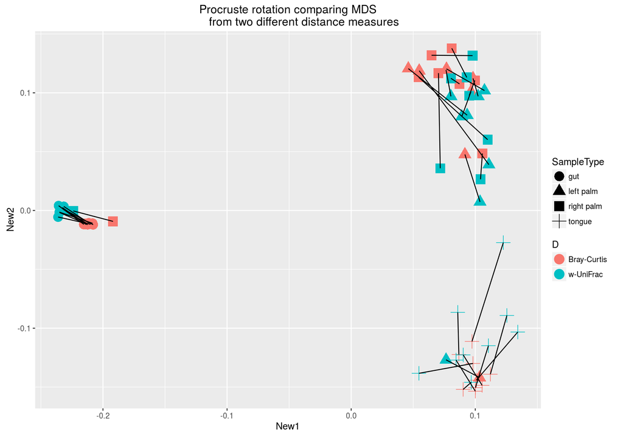

```r
# Order both tables by sample ID
setkey(ordBCdt, SampleID)
setkey(ordUFdt, SampleID)
pro1 <- ade4::procuste(dfX = ordBCdt[, list(Axis.1, Axis.2)],
                       dfY = ordUFdt[, list(Axis.1, Axis.2)])
# Add the procruste rotated and scaled coordinates to each table
ordBCdt[, c("New1", "New2") := pro1$tabX]
ordUFdt[, c("New1", "New2") := pro1$tabY]
# Combine the tables for plottiing
ordBCdt[, D := "Bray-Curtis"]
ordUFdt[, D := "w-UniFrac"]
keepCols = c("New1", "New2", "SampleID", "D", "SampleType",
             "DaysSinceExperimentStart", "Subject", "ReportedAntibioticUsage")
procrustdt = rbindlist(list(ordBCdt[, keepCols, with = FALSE],
                            ordUFdt[, keepCols, with = FALSE]))
# Now define the ggplot object,
# connecting points with the same sample ID, but different distances
ggplot(procrustdt, aes(New1, New2,
                       color = D, shape = SampleType)) +
  geom_point(size = 5) +
  geom_line(aes(group = SampleID), color = "black") +
  ggtitle("Procruste rotation comparing MDS
          from two different distance measures")
```